# Analysis of published YBX1 PARCLIP data

This document describes exploration of some PARCLIP data from a published study (PMID: 31358969). The paper performed a few different analyses related to YBX1, but here we will focus on their PARCLIP data that was performed in duplicate. The raw data for the PARCLIP experiments were uploaded to GSE133671, but unfortunately, they only give basic peak call files that are lacking any sort of scores or information on how they were parsed. As a result, I reprocessed the raw sequencing data using the script found [here](https://github.com/chrishuges/projectsWorkspace/blob/master/sorensenLab/relatedToYbx1/20200526_explorationYbx1ParclipPublished/rawSequencingDataProcessingShellScript.md).

## Linked analysis

This file is a continuation of the work done in:

- 20200525_explorationYbx1ParclipPublished

## Setting up the environment

These are packages you will need for this notebook. For exact versions used, please refer to the session info at the bottom of this notebook.

I want to set a base directory that we can use as a link to the directory where we will do most of the work. I use two directories here because the Workspace is what is pushed to GitHub and contains scripts and plot files, but the Repository is where more of the big data is stored that does not get pushed.

```r
baseWorkspace = 'C:/Users/chris/OneDrive/Documents/bccrc/projectsWorkspace/sorensenLab/relatedToYbx1'
baseRepository = 'C:/Users/chris/OneDrive/Documents/bccrc/projectsRepository/sorensenLab/relatedToYbx1'
```

Lastly, we need to call a source file that has some functions we will need. For simplicity and ease of tracking, I make a copy of this file in each directory that I will work in in order to be able to trace the exact one functions that are used, in case I change them and mistakenly don’t push it to GitHub.

```r
source(paste(baseWorkspace, '/20200526_explorationYbx1ParclipPublished/userDefinedFunctions.R', sep = ''))
```

## Data processing

First we need to build a transcriptome index that we will use for gene assignment in one of the referenced functions. Use the help function for this to find a server that is close to you, it makes a big difference in the speed. I decided to go back and redo the alignment for these data against hg38 because I suspected there was some funny stuff happening with the annotation index that I used in the wavclusterPeakAnnotation function below. I have also rewritten this function to ensure it is operating correctly.

```r
txdbEnsembl = makeTxDbFromEnsembl(organism = 'Homo sapiens',
                                  release = 100,
                                  server = 'useastdb.ensembl.org')
```

```
Fetch transcripts and genes from Ensembl ... OK
Fetch exons and CDS from Ensembl ... OK
Fetch chromosome names and lengths from Ensembl ...OK
Gather the metadata ... OK
Make the TxDb object ... OK
```

```r
#now save the txdb for later use
saveDb(txdbEnsembl, file = paste(baseRepository,
                                 '/20200526_explorationYbx1ParclipPublished/TxDb.Hsapiens.ENSEMBL.hg38.v100.sqlite', sep = ''))
```

```
TxDb object:
# Db type: TxDb
# Supporting package: GenomicFeatures
# Data source: Ensembl
# Organism: Homo sapiens
# Ensembl release: 100
# Ensembl database: homo_sapiens_core_100_38
# MySQL server: useastdb.ensembl.org
# transcript_nrow: 250776
# exon_nrow: 832930
# cds_nrow: 852325
# Db created by: GenomicFeatures package from Bioconductor
# Creation time: 2020-05-26 15:21:05 -0700 (Tue, 26 May 2020)
# GenomicFeatures version at creation time: 1.38.2
# RSQLite version at creation time: 2.2.0
# DBSCHEMAVERSION: 1.2
```

Annotate the YBX1 PARCLIP data that was obtained from wavClusteR using functions defined in the source file referenced above.

```r
#########################################################################################
##get the data for the two replicates
parclip1 = readRDS(paste(baseRepository, '/20200526_explorationYbx1ParclipPublished/SRR9623531.wavClusters.rds', sep = ''))
parclip2 = readRDS(paste(baseRepository, '/20200526_explorationYbx1ParclipPublished/SRR9623532.wavClusters.rds', sep = ''))

##overlap the replicates to only retain regions identified in both
parclipIntersect = GenomicRanges::intersect(parclip1, parclip2)

##in case you don't have the txdb loaded in already
txdbEnsembl = loadDb(file = paste(baseRepository,
                                 '/20200526_explorationYbx1ParclipPublished/TxDb.Hsapiens.ENSEMBL.hg38.v100.sqlite', sep = ''))
##now annotate this with our user-defined function
parclipAnnotated = wavclusterPeakAnnotation(as_tibble(parclipIntersect), txdbEnsembl, removeMito = TRUE)
```

```
Removing chromosome M hits.
Annotating fiveUTR hits.
Finding the longest transcript associated with each input gene in the txdb.
Core set of long transcripts assembled. Data returned.
Annotating the input txdb.
Filtering input txdb to keep only longest transcripts.
Returning the annotated txdb for alignment.
Annotation index for fiveUTR created.
Annotating fiveUTR overlap hits.
Annotation for fiveUTR complete.
Annotating CDS hits.
Annotating the input txdb.
Filtering input txdb to keep only longest transcripts.
Returning the annotated txdb for alignment.
Annotation index for CDS created.
Annotating CDS overlap hits.
Annotation for CDS complete.
Annotating threeUTR hits.
Annotating the input txdb.
Filtering input txdb to keep only longest transcripts.
Returning the annotated txdb for alignment.
Annotation index for threeUTR created.
Annotating threeUTR overlap hits.
Annotation for threeUTR complete.
Combining the data sets and performing the final calculations
Processing complete
```

Remove clusters that are too small and add read counts based on the replicates.

```r
############################################################################
##remove clusters that are too small
parclipLargeClusters = subset(parclipAnnotated, parclipAnnotated$width >= 12)

##read the raw bam files
bampath1 = paste(baseRepository, '/20200526_explorationYbx1ParclipPublished/SRR9623531.trimmed.rrna.bowtie.mapped.sorted.bam', sep = '')
bampath2 = paste(baseRepository, '/20200526_explorationYbx1ParclipPublished/SRR9623532.trimmed.rrna.bowtie.mapped.sorted.bam', sep = '')

##get the max read count in a region, replicate 1
bamCoverage1 = bamCoverage(bampath1, makeGRangesFromDataFrame(parclipLargeClusters), verbose=FALSE)
bamCounts1 = unlist(lapply(as.list(bamCoverage1), max))
parclipLargeClusters$readCountRep1 = bamCounts1

##get the max read count in a region, replicate 2
bamCoverage2 = bamCoverage(bampath2, makeGRangesFromDataFrame(parclipLargeClusters), verbose=FALSE)
bamCounts2 = unlist(lapply(as.list(bamCoverage2), max))
parclipLargeClusters$readCountRep2 = bamCounts2

##combine with the original data and take the sum of the replicates
parclipLargeClusters$readCountSum = as.integer(rowSums(parclipLargeClusters[,c('readCountRep1','readCountRep2')], na.rm = TRUE))
```

Now annotate the location in the read peak where the maximum read count is observed, for each peak.

```r
############################################################################
###find the max location for each peak
bamMax1 = unlist(lapply(as.list(bamCoverage1), function(x) as.integer(mean(which(x == max(x))))))
bamMax2 = unlist(lapply(as.list(bamCoverage2), function(x) as.integer(mean(which(x == max(x))))))
parclipLargeClusters$peakMaxRep1 = parclipLargeClusters$start + bamMax1
parclipLargeClusters$peakMaxRep2 = parclipLargeClusters$start + bamMax2
```

Now annotate the purity for each gene. This is a bit rough, but for all the peaks in each gene, it basically calculates what proportion they contribute to the total signal of that gene. If a gene just has non-specific reads across it, I expect that the peaks will all have low proportion scores. If there are a couple of large peaks, then I expect these to rise above and have higher scores. It is not perfect, and I can envision a couple scenarios where it will fall down, but I think as long as I am not too strict in the filter level it should be ok.

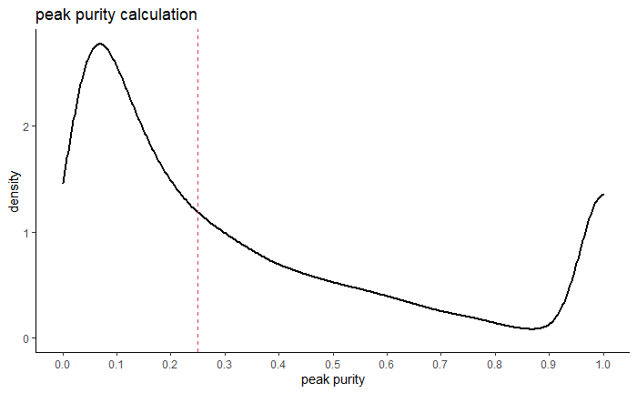

```r
############################################################################
##find the purity for all peaks within a gene
gnSet = unique(parclipLargeClusters$txdbSymbol)
parclipPurity = tibble()
for (i in 1:length(gnSet)){
  purityCalculation = parclipLargeClusters[parclipLargeClusters$txdbSymbol == gnSet[i],] %>%
    arrange(desc(readCountSum)) %>%
    mutate(peakPurity = readCountSum / sum(readCountSum))
  parclipPurity = rbind(parclipPurity, purityCalculation)
}

###make a quick plot of the purity values
ggplot(parclipPurity, aes(peakPurity)) +
  geom_density(size = 1) +
  scale_x_continuous(limits = c(0,1), breaks = seq(0,1,0.1)) +
  labs(x = 'peak purity', y = 'density', title = 'peak purity calculation') +
  geom_vline(xintercept = 0.25, linetype = 'dashed', color = brewer.pal(9,'Spectral')[1]) +
  theme_classic()
ggsave(paste(baseWorkspace, '/20200526_explorationYbx1ParclipPublished/density_yb1Parclip_peakPurityScores.pdf', sep = ''),
       useDingbats = FALSE,
       width = 4,
       height = 4)
```

Now I can assign the peak rank. This is essentially just the rank of all peaks assigned to a single gene, based on their read counts.

```r
############################################################################
##now assign the peak rank
parclipPurityFiltered = parclipPurity %>% filter(peakPurity >= 0.25)
gnSet = unique(parclipPurityFiltered$txdbSymbol)
parclipPeakRank = tibble()
for (i in 1:length(gnSet)){
  purityFilter = parclipPurityFiltered[parclipPurityFiltered$txdbSymbol == gnSet[i],] %>%
    arrange(desc(readCountSum)) %>%
    mutate(peakRank = seq(1,length(readCountSum),1))
  parclipPeakRank = rbind(parclipPeakRank, purityFilter)
}

###this is the final dataset, save it
saveRDS(parclipPeakRank,
        paste(baseRepository, '/20200526_explorationYbx1ParclipPublished/dataset_yb1ParclipAnnotatedPeakSet.rds', sep = ''))
write.table(parclipPeakRank,
        paste(baseRepository, '/20200526_explorationYbx1ParclipPublished/dataset_yb1ParclipAnnotatedPeakSet.csv', sep = ''),
        col.names = TRUE, row.names = FALSE, quote = FALSE, sep = ',')
```

[session information not shown]